# HW 08/09

Author

Kamran Acito

```r
library(tidyverse)
library(here)
library(moderndive)
library(infer)
theme_set(theme_minimal())
```

# Chapter 8

## Question 1

```r
set.seed(1108)

poll <- tibble(
  vote_gop = rbinom(n = 1000,
                    size = 1,
                    prob = .53))
```

Lets do the bootstrap resampling:

```r
set.seed(1108)
bootstrap_dist <- poll %>%
  rep_sample_n(size = nrow(poll), replace = TRUE, reps = 1000) %>%
  group_by(replicate) %>%
  summarize(mean_vote = mean(vote_gop))
```

Now, lets calculate the 95% confidence interval:

```r
conf_int_one <- quantile(bootstrap_dist$mean_vote, c(.025, .975))
print(conf_int_one)
```

```
    2.5%    97.5%
0.483975 0.548000
```

Here I got a confidence interval of (0.483975, 0.548000).

Now, lets use a different approach:

```r
set.seed(1108)
conf_int_two <- poll %>%
  specify(response = vote_gop) %>%
  generate(reps = 1000, type = "bootstrap") %>%
  calculate(stat = "mean") %>%
  get_ci(level = 0.95, type = "percentile")

print(conf_int_two)
```

```
# A tibble: 1 × 2
  lower_ci upper_ci
     <dbl>    <dbl>
1    0.484    0.548
```

Here, I got a confidence interval of (0.483975, 0.548).

Both confidence intervals are the same but if setting the wrong seed will result in different confidence intervals. Setting different seeds will cause the program to generate different samples.

```r
rap_poll <- read_csv("https://raw.githubusercontent.com/rfordatascience/tidytuesday/master/data/2020/2020-04-14/polls.csv")
```

```r
num_one_songs <- rap_poll %>%
  filter(rank == 1)
```

## Question 2

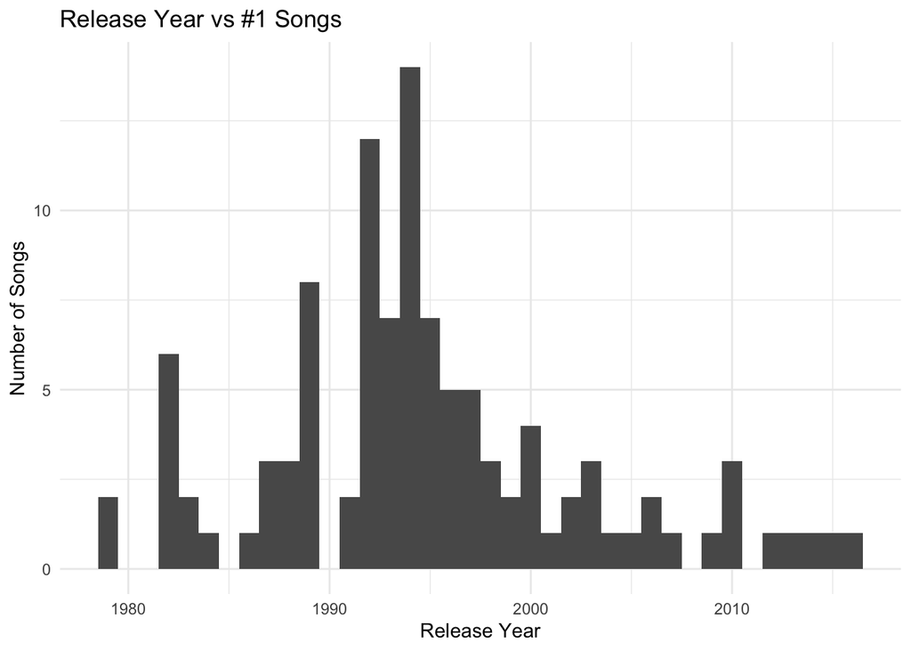

```r
tracks_years <- ggplot(num_one_songs,
                aes(x = year)) +
  geom_histogram(binwidth = 1,
                 center = 0) +
  labs(title = "Release Year vs #1 Songs",
       x = "Release Year",
       y = "Number of Songs")
tracks_years
```

1994 had the most frequently picked favorite track by critics with 14.

## Question 3

```r
set.seed(3)
conf_int_peakofrap <- num_one_songs %>%
  specify(response = year) %>%
  generate(reps = 1000, type = "bootstrap") %>%
  calculate(stat = "mean")
```

```r
confidence_interval <- conf_int_peakofrap %>%
  get_ci(level = 0.95, type = "percentile")
print(confidence_interval)
```

```
# A tibble: 1 × 2
  lower_ci upper_ci
     <dbl>    <dbl>
1    1993.    1996.
```

The lower bound is 1993 and the upper bound is 1996.

## Question 4

```r
conf_int_q4 <- rap_poll %>%
  rep_sample_n(size = 25, reps = 1000, replace = TRUE) %>%
  group_by(replicate) %>%
  summarize(mean_year = mean(year))

ci_25 <- quantile(conf_int_q4$mean_year, c(.025, .975))
print(ci_25)
```

```
    2.5%    97.5%
1994.440 2001.521
```

This created a lower bound of 1994 and an upper bound of 2002.

# Chapter 9

```r
pl_data <- read_csv("https://raw.githubusercontent.com/vaiseys/dav-course/main/Data/premier_league.csv")
glimpse(pl_data)
```

```
Rows: 380
Columns: 4
$ home_team  <chr> "Bournemouth", "Chelsea", "Everton", "Leicester", "Man Unit…
$ away_team  <chr> "Aston Villa", "Swansea", "Watford", "Sunderland", "Tottenh…
$ score_diff <dbl> -1, 0, 0, 2, 1, -2, -2, 0, -1, -3, -1, -3, -2, 2, 0, 0, -1,…
$ result     <chr> "aw", "d", "d", "hw", "hw", "aw", "aw", "d", "aw", "aw", "a…
```

## Question 5

```r
home_wins <- pl_data %>%
  filter(result == "hw")

prop_home_wins <- nrow(home_wins) / nrow(pl_data)

print(prop_home_wins)
```

```
[1] 0.4131579
```

The proportion of home wins for this season (2015/2016) was .4132 or 41.32%.

```r
set.seed(22)

sampled_proportions <- c()

for (i in 1:1000) {

  sampled_results <- sample(c("aw", "hw" , "d"),
                            size = 380,
                            replace = TRUE,
                            prob = c(1/3,1/3,1/3))
  prop <- sum(sampled_results == "hw")/380
  sampled_proportions[i] <- prop

}
```

```r
prop_eqaul_home <- data.frame(Proportion = sampled_proportions)
```

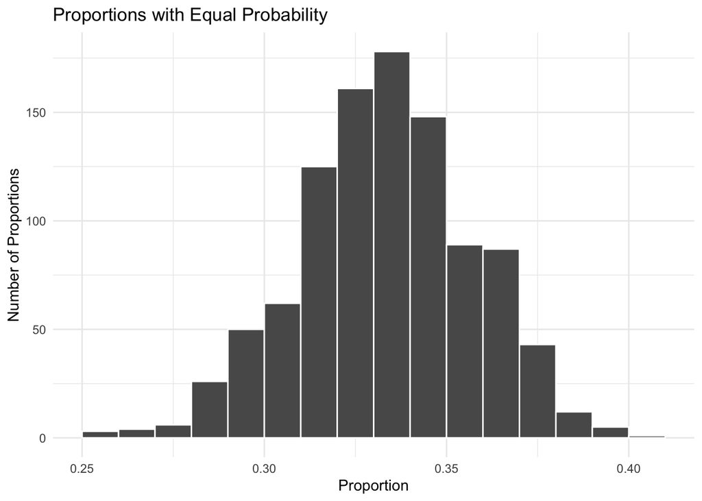

```r
prop_graph <- ggplot(prop_eqaul_home,
                            aes(x = Proportion)) +
  geom_histogram(binwidth = 0.01, boundary = 0.1, color = "white") +
  labs(title = "Proportions with Equal Probability",
       x = "Proportion",
       y = "Number of Proportions")
prop_graph
```

This histogram looks normally distributed. Will large sample sizes we expect the distribution to approach the mean due to the central limit theorem. The proportion in Q5 was higher than the propertions in Q6. This is logical in the real world because teams are generally more likely to win at home rather than away.

## Question7

The null hypothesis would be that both the home and away teams win at the same rate. The alternative hypothesis would be that the home and away teams win at different rates.

## Question 8

In this example, the p-value represents that the probability of the proportion of home wins is higher than the probability of the proportion of away wins as opposed to the proportion of home wins when all results have equal probability. In our scenario we had a two sided test.